# Assignment_1

## COMP41680 - Assignment 1

## Data Extraction Through Web API

#### Student Name(s) : Chaitra Chandrakanth, Swathi Ramachandra Upadhya

#### Student Id(s) : 18200484, 18200264

#### Import Packages

```python
import requests
import json, os
import numpy as np
import pandas as pd
import seaborn as sns
import plotly as py
import plotly.graph_objs as go
import plotly.io as pio
import matplotlib.pyplot as plt

from math import floor
from wordcloud import WordCloud
from IPython.display import Image
from plotly.offline import iplot, init_notebook_mode
py.offline.init_notebook_mode(connected=True)
```

#### **Task 1 : Identify one or more suitable web API(s)**

Selected API(s):

We have chosen 2 APIs provided by the **www.themoviedb.org** namely -

1. discover API (https://developers.themoviedb.org/3/discover/movie-discover)
2. movie API (https://developers.themoviedb.org/3/movies/get-movie-details)

We first use the *discover API* to discover the movie IDs which have scored the highest revenue in 3 time intervals:

1. 1st January 1990 to 31st December 1999
2. 1st January 2000 to 31st December 2009
3. 1st January 2010 to 15th March 2019

Then, we collect the raw data comprising of the movie details and the corresponding credit details based on the stored movie IDs using the *movie API*.

The only constraint to use the APIs is that only **40 requests every 10 seconds is allowed** for a given API key.

The API key we've received is - *bad544be67a002b54b43a14711a515d3*

#### **Task 2: Collect data through the chosen API(s)**

#### Fields

String variables to generate the API URL

```python
#We use 2 different APIs provided by TMDB website namely Discover and Movie APIs

#Discover API
tmdb_discover_api = "https://api.themoviedb.org/3/discover/movie"
#Movie API
tmdb_movie_api = "https://api.themoviedb.org/3/movie/"
#API Key obtained from the website
api_key = "?api_key=bad544be67a002b54b43a14711a515d3"
```

File names

```python
#file storing all the movie details
tmdb_movies_json = "TMDB_Movies.json"
#file storing the movie credit details in the same order
tmdb_credits_json = "TMDB_Credits.json"
```

#### Methods to collect data

Collect data from TMDB based on the from and to date specified as parameters using the *discover* API

Note: The data is collected for movies grossing high revenues in the specified time interval.

```python
#If no to_date is specified, we take 15th March 2019 as the default to_date
def collect_tmdb_data(from_date, to_date="2019-03-15"):
    #We obtain movies data based on the release dates and highest revenue
    highestRevenueUrl= tmdb_discover_api + api_key + '&primary_release_date.gte=' + from_date + '&primary_release_date.lte=' + to_date + '&sort_by=revenue.desc&page='
    movie_ids = []

    print("Collection of raw data from ",from_date,"to ",to_date, "has begun...")

    #Collecting data from 75 pages to obtain details of total 1500 movies
    for page in range(1,76):
        response = requests.get(highestRevenueUrl + str(page))
        highest_revenue_movies = response.json()
        movies = highest_revenue_movies['results']

        #Collect the Ids of each movies listed on the page
        for i in range(len(movies)):
            movie_ids.append(movies[i]["id"])

    #Return the individual movie details and corresponding credit details
    return collect_movie_details(movie_ids)
```

Collect individual movie details and the corresponding credit details using the *movie* API

```python
def collect_movie_details(movie_ids):
    movie_details = []
    credit_details = []

    for id in movie_ids:
        #For each movie based on the movie Id obtain the movie details
        response = requests.get(tmdb_movie_api + str(id) + api_key)
        movie_details.append(response.json())
        #For each movie based on the movie Id obtain the credit details
        response = requests.get(tmdb_movie_api + str(id) + "/credits" + api_key)
        credit_details.append(response.json())

    print("Collection of raw data has ended.")
    #Return the movie details and corresponding credit details as a tuple
    return movie_details, credit_details;
```

#### **Task 3: Parse and store the data**

Method to store the data

```python
def write_data_to_json(movie_details, credit_details):
    #Writing movie details to a JSON file
    with open(tmdb_movies_json, mode='a') as file:
        file.write(json.dumps(movie_details, indent=2))
    #Writing credit details to a JSON file
    with open(tmdb_credits_json, mode='a') as file:
        file.write(json.dumps(credit_details, indent=2))
```

Collecting movie and corresponding credit details from 1st January 2010 to 15th March 2019

```python
#Commenting the code for data collection as it takes 2 hours to collect the data
#movie_details_1, credit_details_1 = collect_tmdb_data('2010-01-01')
```

```
Collection of raw data from  2010-01-01 to  2019-03-15 has begun...
Collection of raw data has ended.
```

Collecting movie and corresponding credit details from 1st January 2000 to 31st December 2009

```python
#Commenting the code for data collection
#movie_details_2, credit_details_2 = collect_tmdb_data(from_date='2000-01-01',
#                                                      to_date='2009-12-31')
```

```
Collection of raw data from  2000-01-01 to  2009-12-31 has begun...
Collection of raw data has ended.
```

Collecting movie and corresponding credit details from 1st January 1990 to 31st December 1999

```python
#Commenting the code for data collection
#movie_details_3, credit_details_3 = collect_tmdb_data(from_date='1990-01-01',
#                                                      to_date="1999-12-31")
```

```
Collection of raw data from  1990-01-01 to  1999-12-31 has begun...
Collection of raw data has ended.
```

Concatenating the lists and writing the contents into a json file

```python
#Commenting the code to concatenate the data collected
#movie_details = movie_details_1 + movie_details_2 + movie_details_3
#credit_details = credit_details_1 + credit_details_2 + credit_details_3
```

```python
#Commenting the code to write the collected data to json file
#write_data_to_json(movie_details, credit_details)
```

#### **Task 4: Load and represent the data using an appropriate data structure**

```python
#Loading the movie details on to a data frame
with open(tmdb_movies_json, "r") as file:
    data = json.load(file)

movies = pd.DataFrame.from_dict(data)
#Using head command to view the top 5 items of our movies dataframe
movies.head()
```

|  | adult | backdrop_path | belongs_to_collection | budget | genres | homepage | id | imdb_id | original_language | original_title | ... | release_date | revenue | runtime | spoken_languages | status | tagline | title | video | vote_average | vote_count |
| --- | --- | --- | --- | --- | --- | --- | --- | --- | --- | --- | --- | --- | --- | --- | --- | --- | --- | --- | --- | --- | --- |
| 0 | False | /njv65RTipNSTozFLuF85jL0bcQe.jpg | {'id': 10, 'name': 'Star Wars Collection', 'po... | 245000000 | [{'id': 28, 'name': 'Action'}, {'id': 12, 'nam... | http://www.starwars.com/films/star-wars-episod... | 140607 | tt2488496 | en | Star Wars: The Force Awakens | ... | 2015-12-15 | 2068223624 | 136.0 | [{'iso_639_1': 'en', 'name': 'English'}] | Released | Every generation has a story. | Star Wars: The Force Awakens | False | 7.4 | 12257 |
| 1 | False | /bOGkgRGdhrBYJSLpXaxhXVstddV.jpg | {'id': 86311, 'name': 'The Avengers Collection... | 300000000 | [{'id': 12, 'name': 'Adventure'}, {'id': 28, '... | http://marvel.com/movies/movie/223/avengers_in... | 299536 | tt4154756 | en | Avengers: Infinity War | ... | 2018-04-25 | 2046239637 | 149.0 | [{'iso_639_1': 'en', 'name': 'English'}] | Released | An entire universe. Once and for all. | Avengers: Infinity War | False | 8.3 | 12208 |
| 2 | False | /t5KONotASgVKq4N19RyhIthWOPG.jpg | {'id': 328, 'name': 'Jurassic Park Collection'... | 150000000 | [{'id': 28, 'name': 'Action'}, {'id': 12, 'nam... | http://www.jurassicworld.com/ | 135397 | tt0369610 | en | Jurassic World | ... | 2015-06-06 | 1671713208 | 124.0 | [{'iso_639_1': 'en', 'name': 'English'}] | Released | The park is open. | Jurassic World | False | 6.6 | 13609 |
| 3 | False | /hbn46fQaRmlpBuUrEiFqv0GDL6Y.jpg | {'id': 86311, 'name': 'The Avengers Collection... | 220000000 | [{'id': 878, 'name': 'Science Fiction'}, {'id'... | http://marvel.com/avengers_movie/ | 24428 | tt0848228 | en | The Avengers | ... | 2012-04-25 | 1519557910 | 143.0 | [{'iso_639_1': 'en', 'name': 'English'}, {'iso... | Released | Some assembly required. | The Avengers | False | 7.6 | 18491 |
| 4 | False | /ypyeMfKydpyuuTMdp36rMlkGDUL.jpg | {'id': 9485, 'name': 'The Fast and the Furious... | 190000000 | [{'id': 28, 'name': 'Action'}, {'id': 80, 'nam... | http://www.furious7.com/ | 168259 | tt2820852 | en | Furious 7 | ... | 2015-04-01 | 1506249360 | 137.0 | [{'iso_639_1': 'en', 'name': 'English'}] | Released | Vengeance Hits Home | Furious 7 | False | 7.3 | 6297 |

5 rows × 25 columns

```python
#Loading the credit details on to a data frame
with open(tmdb_credits_json, "r") as file:
    data = json.load(file)

credits = pd.DataFrame.from_dict(data)
#Using head command to view the top 5 items of our movies dataframe
credits.head()
```

|  | cast | crew | id |
| --- | --- | --- | --- |
| 0 | [{'cast_id': 8, 'character': 'Han Solo', 'cred... | [{'credit_id': '52fe4a959251416c750e7123', 'de... | 140607 |
| 1 | [{'cast_id': 1, 'character': 'Tony Stark / Iro... | [{'credit_id': '544fe93dc3a36802360024f4', 'de... | 299536 |
| 2 | [{'cast_id': 10, 'character': 'Owen Grady', 'c... | [{'credit_id': '52fe4bf7c3a368484e1a066b', 'de... | 135397 |
| 3 | [{'cast_id': 46, 'character': 'Tony Stark / Ir... | [{'credit_id': '52fe4495c3a368484e02b1a1', 'de... | 24428 |
| 4 | [{'cast_id': 17, 'character': 'Dominic Toretto... | [{'credit_id': '52fe4cc8c3a36847f823e681', 'de... | 168259 |

Combining the two dataframes - movies and their corresponding credits

```python
#Combine the datframes based on the id column in both - movie and credits dataframes
combined = pd.merge(movies, credits, left_on = 'id', right_on = 'id')
#Setting the title as index of the dataframe
combined = combined.set_index('title')
```

**Data Wrangling**

```python
#Checking the contents of the combined dataframe
combined.head()
```

| title | adult | backdrop_path | belongs_to_collection | budget | genres | homepage | id | imdb_id | original_language | original_title | ... | revenue | runtime | spoken_languages | status | tagline | video | vote_average | vote_count | cast | crew |
| --- | --- | --- | --- | --- | --- | --- | --- | --- | --- | --- | --- | --- | --- | --- | --- | --- | --- | --- | --- | --- | --- |
| Star Wars: The Force Awakens | False | /njv65RTipNSTozFLuF85jL0bcQe.jpg | {'id': 10, 'name': 'Star Wars Collection', 'po... | 245000000 | [{'id': 28, 'name': 'Action'}, {'id': 12, 'nam... | http://www.starwars.com/films/star-wars-episod... | 140607 | tt2488496 | en | Star Wars: The Force Awakens | ... | 2068223624 | 136.0 | [{'iso_639_1': 'en', 'name': 'English'}] | Released | Every generation has a story. | False | 7.4 | 12257 | [{'cast_id': 8, 'character': 'Han Solo', 'cred... | [{'credit_id': '52fe4a959251416c750e7123', 'de... |
| Avengers: Infinity War | False | /bOGkgRGdhrBYJSLpXaxhXVstddV.jpg | {'id': 86311, 'name': 'The Avengers Collection... | 300000000 | [{'id': 12, 'name': 'Adventure'}, {'id': 28, '... | http://marvel.com/movies/movie/223/avengers_in... | 299536 | tt4154756 | en | Avengers: Infinity War | ... | 2046239637 | 149.0 | [{'iso_639_1': 'en', 'name': 'English'}] | Released | An entire universe. Once and for all. | False | 8.3 | 12208 | [{'cast_id': 1, 'character': 'Tony Stark / Iro... | [{'credit_id': '544fe93dc3a36802360024f4', 'de... |
| Jurassic World | False | /t5KONotASgVKq4N19RyhIthWOPG.jpg | {'id': 328, 'name': 'Jurassic Park Collection'... | 150000000 | [{'id': 28, 'name': 'Action'}, {'id': 12, 'nam... | http://www.jurassicworld.com/ | 135397 | tt0369610 | en | Jurassic World | ... | 1671713208 | 124.0 | [{'iso_639_1': 'en', 'name': 'English'}] | Released | The park is open. | False | 6.6 | 13609 | [{'cast_id': 10, 'character': 'Owen Grady', 'c... | [{'credit_id': '52fe4bf7c3a368484e1a066b', 'de... |
| The Avengers | False | /hbn46fQaRmlpBuUrEiFqv0GDL6Y.jpg | {'id': 86311, 'name': 'The Avengers Collection... | 220000000 | [{'id': 878, 'name': 'Science Fiction'}, {'id'... | http://marvel.com/avengers_movie/ | 24428 | tt0848228 | en | The Avengers | ... | 1519557910 | 143.0 | [{'iso_639_1': 'en', 'name': 'English'}, {'iso... | Released | Some assembly required. | False | 7.6 | 18491 | [{'cast_id': 46, 'character': 'Tony Stark / Ir... | [{'credit_id': '52fe4495c3a368484e02b1a1', 'de... |
| Furious 7 | False | /ypyeMfKydpyuuTMdp36rMlkGDUL.jpg | {'id': 9485, 'name': 'The Fast and the Furious... | 190000000 | [{'id': 28, 'name': 'Action'}, {'id': 80, 'nam... | http://www.furious7.com/ | 168259 | tt2820852 | en | Furious 7 | ... | 1506249360 | 137.0 | [{'iso_639_1': 'en', 'name': 'English'}] | Released | Vengeance Hits Home | False | 7.3 | 6297 | [{'cast_id': 17, 'character': 'Dominic Toretto... | [{'credit_id': '52fe4cc8c3a36847f823e681', 'de... |

5 rows × 26 columns

```python
#Checking the columns and their corresponding data type
combined.info()
```

```
<class 'pandas.core.frame.DataFrame'>
Index: 4500 entries, Star Wars: The Force Awakens to Darawani Haveli
Data columns (total 26 columns):
adult                    4500 non-null bool
backdrop_path            4404 non-null object
belongs_to_collection    1120 non-null object
budget                   4500 non-null int64
genres                   4500 non-null object
homepage                 1747 non-null object
id                       4500 non-null int64
imdb_id                  4494 non-null object
original_language        4500 non-null object
original_title           4500 non-null object
overview                 4500 non-null object
popularity               4500 non-null float64
poster_path              4495 non-null object
production_companies     4500 non-null object
production_countries     4500 non-null object
release_date             4500 non-null object
revenue                  4500 non-null int64
runtime                  4476 non-null float64
spoken_languages         4500 non-null object
status                   4500 non-null object
tagline                  4500 non-null object
video                    4500 non-null bool
vote_average             4500 non-null float64
vote_count               4500 non-null int64
cast                     4500 non-null object
crew                     4500 non-null object
dtypes: bool(2), float64(3), int64(4), object(17)
memory usage: 887.7+ KB
```

**Information regarding the features of the combined dataset**

**adult** : indicates whether it is an adult movie or not

**backdrop_path** : contains the path to the image of the backdrop

**belongs_to_collection** : information regarding the collection to which the movie belongs i.e., if it is a sequel to some other movie or collection

**budget** : budget of the movie

**genres** : list of all the genres which is applicable to the movie

**homepage** : contains the link to the homepage of the movie

**id** : unique ID of the movie in the TMDB website

**imdb_id** : unique ID of the movie in IMDB website

**original_language** : language in which the movie was originally released

**original_title** : original title given to the movie

**overview** : description of the movie plot

**popularity** : indicates the popularity of the movie; higher the value greater is the popularity

**poster_path** : link containing the poster of the movie

**production_companies** : dictionary values of the companies involved in the production of the movie

**production_countries** : dictionary values containing the name and the ISO code of the countries involved in the production of the movie

**release_date** : date when the movie was released

**revenue** : revenue earned by the release of the movie

**runtime** : the time period for which the movie has run in the theatres

**spoken_languages** : langugaes spoken in the movie

**status** : indicates the status of the movie - Released or not

**tagline** : tagline of the movie

**video** : boolean value indicating if there are any videos present for the movie

**vote_average** : indicates the mean rating received for the movie

**vote_count** : indicates the number of votes/rating received for the movie

**cast** : dictionary containing information of all the cast members of the movie and their TMDB unique cast id

**crew** : dictionary containing information of all the crew members of the movie and their TMDB unique crew id

```python
#Checking the dimensions of the dataframe
combined.shape
```

```
(4500, 26)
```

**Data Cleaning**

Obtain information from columns containing dictionaries

```python
def get_values(items, isList=True):
    """Gets the values with the key 'name' for the parameter specified
       Parameters
        ----------
        items : dictionary OR list of dictionary items
        isList : boolean value representing if the items is a list or not
       Returns
        -------
        values : list of the values as a string where multiple values are separated by '|'.
            The values for given set of items. """
    values = []
    #Checking if the items is not null
    if(items!=None):
        #If the items contains a list, then iterate through each item and collect all values
        if(isList):
            for item in items:
                values.append(item['name'])
        #Else just append a single value
        else:
            values.append(items['name'])
    #If item is null, append 'None'
    else:
        values.append('None')
    #Returns the list seaprating multiple values with a pipe
    return '|'.join(values)
```

```python
#Obtaining the values for every column present as a dictionary or list of dictionaries
#in the uncleaned dataframe
combined['genres'] = combined['genres'].apply(get_values)
combined['production_companies'] = combined['production_companies'].apply(get_values)
combined['production_countries'] = combined['production_countries'].apply(get_values)
combined['belongs_to_collection'] = combined['belongs_to_collection'].apply(get_values,
                                                                            isList=False)
```

Obtain actor and director information

```python
def get_actor(items, order=0):
    """Gets the actor name for every movie
       Parameters
        ----------
        items : list of dictionary items
        The cast  details
        order : order specified for the actor
       Returns
        -------
        The name of the actor for the specfied order"""
    #If
    if(items==None):
        return
    for item in items:
        if item["order"] == order:
            return item["name"]

def get_director(items):
    """Gets the director name for every movie from the given crew details
       Parameters
        ----------
        items : list of dictionary items
        The crew  details
       Returns
        -------
        The name of the director"""
    directors = [x['name'] for x in items if x['job'] == 'Director']
    if(len(directors) > 0):
        return directors[0]
```

```python
#Obtain the naes of two protagonist of the movies
combined['actor1'] = combined['cast'].apply(get_actor, order=1)
combined['actor2'] = combined['cast'].apply(get_actor, order=2)
#Obtain the name of the director of the movie
combined['director'] = combined['crew'].apply(get_director)
```

Column Manipulations

```python
#Extracting Profit earned
combined['profit'] = combined['revenue'] - combined['budget']
```

```python
#Converting release_date column to release_year
combined['release_year'] = pd.to_datetime(combined['release_date']).dt.year
```

```python
#Assigning Missing values to empty strings in genres
def replace_empty_genres_with_NaN(item):
    """Replaces the genre values containing empty strings with np.NaN values
    Parameters
    ----------
     items : string of genre values
    Returns
     -------
     Returns NaN if item is an empty string else returns the original item"""
    if item == '':
        return np.NaN
    else:
        return item

#Converts the empty strings present in genres with NaN values so that it's easy to preprocess
combined['genres'] = combined['genres'].apply(replace_empty_genres_with_NaN)
```

Dropping columns that we shall not use for our analysis

```python
# There are 17 columns from the existing dataset that we shall not use in our analysis
combined.drop(['backdrop_path','crew', 'cast', 'production_countries', 'homepage', 'id',
               'imdb_id', 'original_language','original_title','overview','poster_path',
               'release_date', 'runtime', 'spoken_languages', 'status', 'tagline','video'],
              axis=1, inplace=True)
```

Checking for null values

```python
combined.isnull().sum()
```

```
adult                     0
belongs_to_collection     0
budget                    0
genres                   13
popularity                0
production_companies      0
revenue                   0
vote_average              0
vote_count                0
actor1                   55
actor2                   74
director                  9
profit                    0
release_year              0
dtype: int64
```

There are 13 rows where *genres* contains null values, 55 rows where *actor1* contains null values, 74 rows where *actor2* contains null and 9 rows where *director* information is null. Since these are textual values and are not very critical for our analysis, we shall drop these rows.

```python
#deleting rows containing null values
combined.dropna(inplace=True)
```

```python
#Checking for duplicate rows
combined.duplicated().sum()
```

```
0
```

```python
#Checking the dimension of the dataframe to know how many records we shall perform our analysis
combined.shape
```

```
(4380, 14)
```

```python
#Checking the contents of the cleaned dataframe
combined.head()
```

| title | adult | belongs_to_collection | budget | genres | popularity | production_companies | revenue | vote_average | vote_count | actor1 | actor2 | director | profit | release_year |
| --- | --- | --- | --- | --- | --- | --- | --- | --- | --- | --- | --- | --- | --- | --- |
| Star Wars: The Force Awakens | False | Star Wars Collection | 245000000 | Action\|Adventure\|Science Fiction\|Fantasy | 30.570 | Truenorth Productions\|Lucasfilm\|Bad Robot | 2068223624 | 7.4 | 12257 | Carrie Fisher | Daisy Ridley | J.J. Abrams | 1823223624 | 2015 |
| Avengers: Infinity War | False | The Avengers Collection | 300000000 | Adventure\|Action\|Fantasy | 139.940 | Marvel Studios | 2046239637 | 8.3 | 12208 | Chris Hemsworth | Mark Ruffalo | Joe Russo | 1746239637 | 2018 |
| Jurassic World | False | Jurassic Park Collection | 150000000 | Action\|Adventure\|Science Fiction\|Thriller | 27.904 | Fuji Television Network\|Amblin Entertainment\|L... | 1671713208 | 6.6 | 13609 | Bryce Dallas Howard | Irrfan Khan | Colin Trevorrow | 1521713208 | 2015 |
| The Avengers | False | The Avengers Collection | 220000000 | Science Fiction\|Action\|Adventure | 63.502 | Marvel Studios | 1519557910 | 7.6 | 18491 | Chris Evans | Mark Ruffalo | Joss Whedon | 1299557910 | 2012 |
| Furious 7 | False | The Fast and the Furious Collection | 190000000 | Action\|Crime\|Thriller\|Drama | 22.618 | Abu Dhabi Film Commission\|Universal Pictures\|C... | 1506249360 | 7.3 | 6297 | Paul Walker | Dwayne Johnson | James Wan | 1316249360 | 2015 |

#### **Task 5: Data Analysis**

NOTE: Plots generated using plotly might not be visible in the Jupyter notebook until executed. For this reason, Jupyter Notebook HTML version is also provided to have a look at the plots. Additionally, the plotly plots are saved in the images folder to verify again.

Analysis based on decade information

```python
#Common variables used for plots
title_font = {'family': 'serif', 'color':  'black', 'weight': 'bold', 'size': 15}
label_font = {'family': 'serif', 'color':  'black', 'weight': 'bold', 'size': 12}
plotly_fontdict = {'family': 'serif', 'color':  'black', 'size': 20}
```

```python
#Create a directory to store the plots created by plotly
if not os.path.exists('images'):
    os.mkdir('images')
```

```python
#Function to get the range in which the year is present
def get_year_range(year):
    """Gets the range(or decade information) in which the specified year lies
    Parameters
    ----------
     year : release_year of the movie
    Returns
     -------
     Returns the string representing the decade information"""
    if 1990 <= year <= 1999:
        return "1990-1999"
    elif 2000 <= year <= 2009:
        return "2000-2009"
    else:
        return "2010-2019"
```

```python
#Function to plot the plotly bar graph
def plot_bar_graph(x, y, path, color, title, xlab, ylab, orient = 'v',
                   bar_gap=0.8, margin={'b' : 90, 'l' : 90}):
    """Plots the plotly bar graph with the specified parameters
    Parameters
    ----------
    x : values to be plotted on the X-axis
    y : values to be plotted on the Y-axis
    color : color of the bars
    title : title of the graph
    xlab : label of the X-axis
    ylab : label of the Y-axis
    orient : Orientation of the bars - vertical is the default value
    bar_gap : controls the width of each bar
     """
    bar_data = [go.Bar(x=x,
                       y=y,
                       orientation = orient,
                       marker=dict(color=color))]
    init_notebook_mode(connected=True)

    layout = go.Layout(title=title, xaxis={'title': xlab , 'titlefont' : plotly_fontdict},
                       yaxis={'title': ylab , 'titlefont' : plotly_fontdict}, margin = margin,
                       bargap=bar_gap)


    figure = go.Figure(data=bar_data, layout=layout)
    pio.write_image(figure, path, format='png')
    iplot(figure)
```

**Change in Vote Count over the decades**

```python
#Deep copy the cleaned dataframe
dataframe = combined.copy(deep=True)
#Update the decade information of each movie
dataframe['release_year'] = dataframe.release_year.apply(get_year_range)
#resetting the year
dataframe.reset_index('title', inplace=True)
#Check if we have proportionate data in each decade
dataframe['release_year'].value_counts()
```

```
2000-2009    1470
2010-2019    1464
1990-1999    1446
Name: release_year, dtype: int64
```

```python
#Group by the decade information and sum the vote_count column
df = dataframe.groupby(['release_year']).vote_count.sum().reset_index()
#Plot the  bar graph for decade vs vote_count
plot_bar_graph(x=df['release_year'], y=df["vote_count"], path="images/vote_count_change.png",
               color='purple', title='Change in Vote Count over the decades',
               xlab='Decade', ylab='Total Votes')
```

[interactive chart not shown]

**Observation:** It can be observed that the vote counts have been increasing over the decades. This decade vote count is greater than ~3.5 times of the vote counts of the 1990s.

**Change in movies' revenue and budget over the decade**

```python
#Deep copy the cleaned dataframe
df = combined.copy(deep=True)
#Groupby the decade and compute mean
df = df.groupby("release_year").mean().reset_index()
#Display top 5 values of the dataframe
df.head()
```

|  | release_year | adult | budget | popularity | revenue | vote_average | vote_count | profit |
| --- | --- | --- | --- | --- | --- | --- | --- | --- |
| 0 | 1990 | False | 1.124714e+07 | 6.598952 | 4.896619e+07 | 5.884800 | 549.056000 | 3.771905e+07 |
| 1 | 1991 | False | 1.208876e+07 | 5.870159 | 3.836128e+07 | 6.015909 | 381.674242 | 2.627252e+07 |
| 2 | 1992 | False | 1.256215e+07 | 6.951190 | 5.179855e+07 | 6.130159 | 420.769841 | 3.923640e+07 |
| 3 | 1993 | False | 1.294036e+07 | 6.711235 | 5.024895e+07 | 6.241611 | 473.744966 | 3.730859e+07 |
| 4 | 1994 | False | 1.692712e+07 | 7.554684 | 6.101703e+07 | 5.955639 | 821.661654 | 4.408991e+07 |

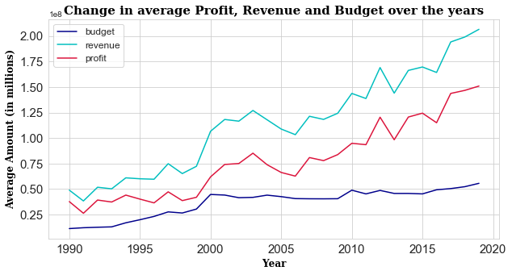

```python
#Using line graphs to plot
fig, ax = plt.subplots(figsize=(10,5))
ax.tick_params(axis = 'both', which = 'major', labelsize = 15)
plt.plot(df.release_year, df.budget, color='DarkBlue')
plt.plot(df.release_year, df.revenue, color='c')
plt.plot(df.release_year, df.profit, color='crimson')
#Set X-axis label
plt.xlabel('Year', fontdict=label_font)
#Set Y-axis label
plt.ylabel('Average Amount (in millions)', fontdict=label_font)
plt.title('Change in average Profit, Revenue and Budget over the years', fontdict=title_font)
plt.legend(prop={'size': 12})
#Display the graph
plt.show()
```

The increase in the budget can also be noticed although it isn't as profound as the change in Revenue and Profit.

**Exploring Genres for each decade**

```python
def decade_based_wordcloud(dataframe):
    """Generates the wordcloud based on frequencies for the genres specified
    in the given dataframe
    Parameters
    ----------
    dataframe : dataframe for whose genres wordcloud is to be created
    Returns
    ----------
    wordcloud of the genres present in the dataframe
     """
    #Create a dictionary of genres and their respective counts
    genres_frequencies = dict(dataframe["genres"].value_counts())
    #Generate word cloud from the frequencies
    wordcloud = WordCloud(width=800, height=600).generate_from_frequencies(genres_frequencies)
    #Return the wordcloud
    return wordcloud
```

```python
#Create a deep copy of the dataframe containing the decade information
repeated_genres_df = dataframe.copy(deep=True)

#Split the genres values based on '|' delimiter and create individual rows for each genre
genre_value = repeated_genres_df['genres'].str.split('|').apply(pd.Series, 1).stack()
genre_value.index = genre_value.index.droplevel(-1)
genre_value.name = 'genres'
#Delete the existing column where all genres are combined using '|'
del repeated_genres_df['genres']

#Join the existing datframe with the respective individual genre values
repeated_genres_df = repeated_genres_df.join(genre_value)
#Display the modified dataframe
repeated_genres_df.head()
```

|  | title | adult | belongs_to_collection | budget | popularity | production_companies | revenue | vote_average | vote_count | actor1 | actor2 | director | profit | release_year | genres |
| --- | --- | --- | --- | --- | --- | --- | --- | --- | --- | --- | --- | --- | --- | --- | --- |
| 0 | Star Wars: The Force Awakens | False | Star Wars Collection | 245000000 | 30.57 | Truenorth Productions\|Lucasfilm\|Bad Robot | 2068223624 | 7.4 | 12257 | Carrie Fisher | Daisy Ridley | J.J. Abrams | 1823223624 | 2010-2019 | Action |
| 0 | Star Wars: The Force Awakens | False | Star Wars Collection | 245000000 | 30.57 | Truenorth Productions\|Lucasfilm\|Bad Robot | 2068223624 | 7.4 | 12257 | Carrie Fisher | Daisy Ridley | J.J. Abrams | 1823223624 | 2010-2019 | Adventure |
| 0 | Star Wars: The Force Awakens | False | Star Wars Collection | 245000000 | 30.57 | Truenorth Productions\|Lucasfilm\|Bad Robot | 2068223624 | 7.4 | 12257 | Carrie Fisher | Daisy Ridley | J.J. Abrams | 1823223624 | 2010-2019 | Science Fiction |
| 0 | Star Wars: The Force Awakens | False | Star Wars Collection | 245000000 | 30.57 | Truenorth Productions\|Lucasfilm\|Bad Robot | 2068223624 | 7.4 | 12257 | Carrie Fisher | Daisy Ridley | J.J. Abrams | 1823223624 | 2010-2019 | Fantasy |
| 1 | Avengers: Infinity War | False | The Avengers Collection | 300000000 | 139.94 | Marvel Studios | 2046239637 | 8.3 | 12208 | Chris Hemsworth | Mark Ruffalo | Joe Russo | 1746239637 | 2010-2019 | Adventure |

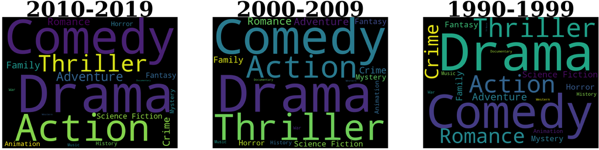

```python
#Setting the initial plotting information
fig = plt.figure(figsize=(150,150))
subPlotIndex = 1
#Defining the conditions for the font used in wordcloud title
font = {'family': 'serif', 'color':  'black', 'weight': 'bold', 'size': 300}

#For every decade, a wordcloud of the corresponding genres is plotted from
#the frequency of occurrence
for decade in repeated_genres_df["release_year"].unique():
    ax = fig.add_subplot(1,3, subPlotIndex)
    genredf = repeated_genres_df[repeated_genres_df['release_year'] == decade]
    wordcloud = decade_based_wordcloud(genredf)

    #Set the title of the wordcloud to the decade information
    ax.set_title(decade, loc = 'center', fontdict=font)
    #Display the wordcloud generated
    ax.imshow(wordcloud)
    ax.axis('off')
    #Increment the subplot index
    subPlotIndex = subPlotIndex + 1
```

**Observation:** The most prominent genres reigning the Box-office for all the 3 decades are - *Drama* and *Comedy*. However, it can be noticed that the frequency of *Romance* genre movies *has reduced* in the 2010s but the movies of *Action* and *Adventure* genres are gaining importance and making good collections at the Box-office.

```python
#Create a deep copy of the dataframe containing the decade information
df = dataframe.copy(deep = True)
#For each decade find the correlation between Popularity and Vote Average
for year_range in df['release_year'].unique():
    #Create a subset of the dataframes containing only one decade's information
    dfsubset = df[df['release_year'] == year_range]
    #Print decade and the correlation between vote_average and popularity obtained
    print("Decade: ", year_range, "Correlation: ",
          dfsubset['vote_average'].corr(dfsubset['profit']))
```

```
Decade:  2010-2019 Correlation:  0.20984388329410864
Decade:  2000-2009 Correlation:  0.24509246027964635
Decade:  1990-1999 Correlation:  0.22044568948010518
```

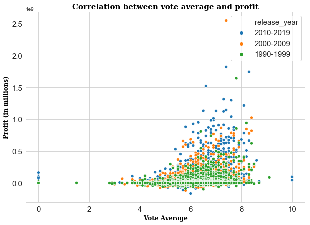

```python
#Create a deep copy of the dataframe containing the decade information
df = dataframe.copy(deep = True)
#Setting initial information of the plot size
fig, ax = plt.subplots(figsize=(10,7))
#Set the back_ground style for seaborn to whitegrid
sns.set_style('whitegrid')
#Plot the scatterplot to show the correlation with each decade information
#represented in different color
sns.scatterplot(x='vote_average', y='profit', data=df, hue='release_year')
plt.xlabel("Vote Average", fontdict=label_font)
plt.ylabel("Profit (in millions)", fontdict=label_font)
ax.set_title("Correlation between vote average and profit", fontdict=title_font)
ax.tick_params(axis = 'both', which = 'major', labelsize = 15)
ax.legend(prop={'size': 15})
#Display the graph
plt.show()
```

**Observation:** Vote Average and Profit seem to have a positive correlation of a small strength over all the decades.

**Production Companies count over the decades**

```python
# create a subset dataframe
company_df = combined.copy(deep=True)
```

```python
#Split the genres values based on '|' delimiter and create individual rows for each genre
comp_value = company_df['production_companies'].str.split('|').apply(pd.Series, 1).stack()
comp_value.index = comp_value.index.droplevel(-1)
comp_value.name = 'production_companies'
#Delete the existing column where all genres are combined using '|'
del company_df["production_companies"]
#Join the existing datframe with the respective individual genre values and resetting the index
company_df= company_df.join(comp_value)
company_df.reset_index('title', inplace=True)
#Display the modified dataframe
company_df.head()
```

|  | title | adult | belongs_to_collection | budget | genres | popularity | revenue | vote_average | vote_count | actor1 | actor2 | director | profit | release_year | production_companies |
| --- | --- | --- | --- | --- | --- | --- | --- | --- | --- | --- | --- | --- | --- | --- | --- |
| 0 | (500) Days of Summer | False | None | 7500000 | Comedy\|Drama\|Romance | 10.841 | 60722734 | 7.2 | 5341 | Zooey Deschanel | Chloë Grace Moretz | Marc Webb | 53222734 | 2009 | Fox Searchlight Pictures |
| 1 | (500) Days of Summer | False | None | 7500000 | Comedy\|Drama\|Romance | 10.841 | 60722734 | 7.2 | 5341 | Zooey Deschanel | Chloë Grace Moretz | Marc Webb | 53222734 | 2009 | Watermark Pictures |
| 2 | (500) Days of Summer | False | None | 7500000 | Comedy\|Drama\|Romance | 10.841 | 60722734 | 7.2 | 5341 | Zooey Deschanel | Chloë Grace Moretz | Marc Webb | 53222734 | 2009 | Dune Entertainment III |
| 3 | 10 Cloverfield Lane | False | None | 15000000 | Thriller\|Science Fiction\|Drama | 15.246 | 108286421 | 6.9 | 4461 | John Goodman | John Gallagher Jr. | Dan Trachtenberg | 93286421 | 2016 | Spectrum Effects |
| 4 | 10 Cloverfield Lane | False | None | 15000000 | Thriller\|Science Fiction\|Drama | 15.246 | 108286421 | 6.9 | 4461 | John Goodman | John Gallagher Jr. | Dan Trachtenberg | 93286421 | 2016 | Paramount |

```python
# Group the release date by range for 10 years and count the total list of companies.
df = company_df.copy(deep=True)
df['release_year'] = df['release_year'].apply(get_year_range)
#Resetting the index after grouping to obtain a dataframe object
df = df.groupby("release_year")["production_companies"].count().reset_index()

#Display the modified dataframe
df.head()
```

|  | release_year | production_companies |
| --- | --- | --- |
| 0 | 1990-1999 | 3423 |
| 1 | 2000-2009 | 5292 |
| 2 | 2010-2019 | 5472 |

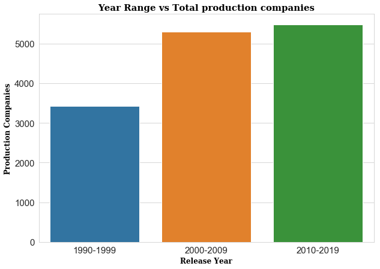

```python
# Plotting the graph for year range vs the total production companies for these years
fig, ax = plt.subplots(figsize=(10,7))
sns.barplot(x=df["release_year"],
            y=df["production_companies"]).set_title("Year Range vs Total production companies",
                                                    fontdict=title_font)
plt.xlabel("Release Year", fontdict=label_font)
plt.ylabel("Production Companies", fontdict=label_font)
ax.tick_params(axis = 'both', which = 'major', labelsize = 15)
```

**Observation:** The number of production companies have increased over the decades.

**Movies produced each year**

```python
#Selecting the required columns
df = company_df[['title', 'profit', 'production_companies', 'release_year']]
```

```python
# Grouping title by the year
value = df.groupby("release_year")['title'].count().reset_index()
value.head()
```

|  | release_year | title |
| --- | --- | --- |
| 0 | 1990 | 262 |
| 1 | 1991 | 301 |
| 2 | 1992 | 278 |
| 3 | 1993 | 315 |
| 4 | 1994 | 291 |

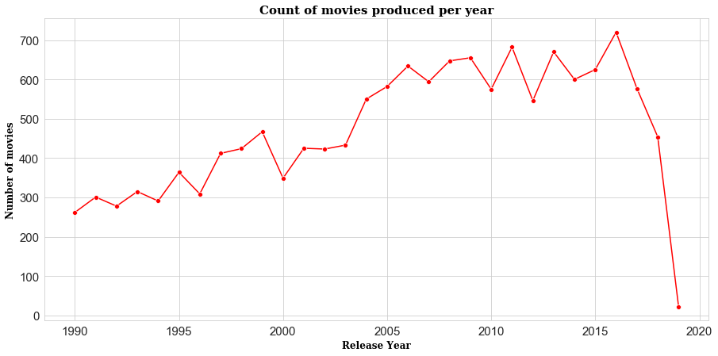

```python
# Plotting the graph for release year and title to see how the trend has changed over years
fig, ax = plt.subplots(figsize=(15,7))
sns.lineplot(x="release_year", y="title", color="red",marker="o",
             data= value).set_title("Count of movies produced per year",
                                    fontdict=title_font)
plt.xlabel("Release Year", fontdict=label_font)
plt.ylabel("Number of movies",fontdict=label_font)
ax.tick_params(axis = 'both', which = 'major', labelsize = 15)
```

**General Movie Analysis**

**Have adult movies gained high revenue?**

```python
combined['adult'].value_counts()
```

```
False    4380
Name: adult, dtype: int64
```

**Observations:** Adult movies have not earned as high revenue as the other movies

**Genres vs Popularity**

```python
#Check unique values of genres in the already existing dataframe
genres = repeated_genres_df['genres'].unique()
#Sort the rows based on genres
genre_values = repeated_genres_df.sort_values(by="genres",ascending=True)
```

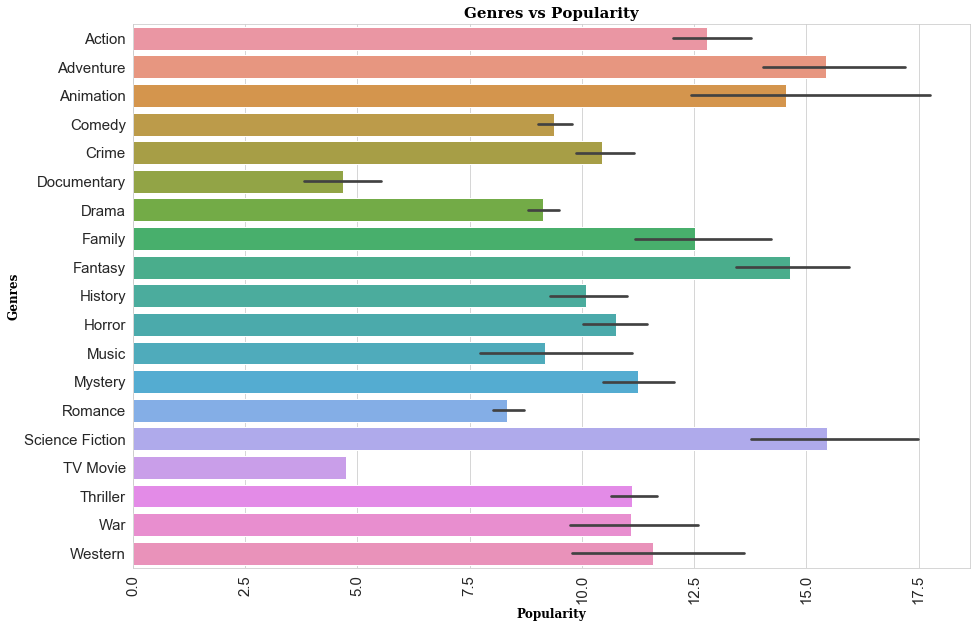

```python
#Setting the initial plotting figure size
fig, ax = plt.subplots(figsize=(15,10))
#Plotting a seaborn barplot for Genres vs Popularity
sns.barplot(x="popularity", y="genres", data= genre_values).set_title("Genres vs Popularity",
                                                                      fontdict=title_font)
plt.xticks(rotation = 90)
plt.xlabel("Popularity", fontdict=label_font)
plt.ylabel("Genres",fontdict=label_font)
ax.tick_params(axis = 'both', which = 'major', labelsize = 15)
```

**Observation:** It can be noted that **Science Fiction** and **Adventure** have been the **most popular genres** which are followed by **Animation** and **Fantasy**.

It is also worth noting that **TV Movie** and **Documentary** have been the **least popular genres**.

**Movies Collection vs Profit**

```python
#Create a deep copy of the dataframe containing the decade information
df = combined.copy(deep=True)
#Group by the collections
df = df.groupby('belongs_to_collection')
#Lists to store the collections and their corresponding profit
collections = []
profit = []

#For every group in the grouped dataframe, append the collections and their profit
#to every valid collections having count more than 4 movies
for collection, group in df:
    if(len(group.index) > 4 and collection != 'None'):
        collections.append(collection)
        profit.append(group['profit'].sum())
#Sort the collections based on profit
collections = [x for _,x in sorted(zip(profit,collections))]
profit = sorted(profit)
```

```python
#Plot a plotly bar graph for the Collections vs their Profit
plot_bar_graph(x=collections, y=profit, path='images/collection_profit.png', color='green',
               title='Collections vs Profit', xlab='Collections', ylab='Profit',
               bar_gap=0.5, margin={'b':160, 'l':100})
```

[interactive chart not shown]

**Observation:** The Harry Potter Collections seems to have grossed the highest revenue of ~6 billion amongst all the collections. This is followed by Star Wars Collection and Jurassic Park Collection.

**Ten most profited movies**

```python
# using the existing data frame actor_df aggregating the profit by the movies title
df = dataframe.copy(deep=True)
#Selecting the required columns only
df = df[['title', 'profit']]
#Grouping by title and computing sum of the profit column
df = df.groupby('title', as_index=False).agg({"profit": "sum"})
```

```python
# Sorting the top 10 movies by profit
df = df.sort_values(by=['profit'], ascending=False)[:10]
```

```python
#Plot a plotly bar graph based on the Profit and movie over 3 decades
plot_bar_graph(color='goldenrod', x=df['title'], xlab="Movies", bar_gap=0.3,
               title="Average profit for top 10 movies over 3 decades",
               y=df['profit'] , ylab="Average Profit",
               path='images/movies_profit.png',
               margin={'b' : 200, 'l' : 100})
```

[interactive chart not shown]

**Observation:** The graph states that Avatar has grossed highest profit in the last 3 decades.

**Cast and Crew Analysis**

**Average Profit for Actors**

```python
# created sub-set of the dataframe
actor_df = dataframe.copy(deep=True)
actor_df.head()
```

|  | title | adult | belongs_to_collection | budget | genres | popularity | production_companies | revenue | vote_average | vote_count | actor1 | actor2 | director | profit | release_year |
| --- | --- | --- | --- | --- | --- | --- | --- | --- | --- | --- | --- | --- | --- | --- | --- |
| 0 | Star Wars: The Force Awakens | False | Star Wars Collection | 245000000 | Action\|Adventure\|Science Fiction\|Fantasy | 30.570 | Truenorth Productions\|Lucasfilm\|Bad Robot | 2068223624 | 7.4 | 12257 | Carrie Fisher | Daisy Ridley | J.J. Abrams | 1823223624 | 2010-2019 |
| 1 | Avengers: Infinity War | False | The Avengers Collection | 300000000 | Adventure\|Action\|Fantasy | 139.940 | Marvel Studios | 2046239637 | 8.3 | 12208 | Chris Hemsworth | Mark Ruffalo | Joe Russo | 1746239637 | 2010-2019 |
| 2 | Jurassic World | False | Jurassic Park Collection | 150000000 | Action\|Adventure\|Science Fiction\|Thriller | 27.904 | Fuji Television Network\|Amblin Entertainment\|L... | 1671713208 | 6.6 | 13609 | Bryce Dallas Howard | Irrfan Khan | Colin Trevorrow | 1521713208 | 2010-2019 |
| 3 | The Avengers | False | The Avengers Collection | 220000000 | Science Fiction\|Action\|Adventure | 63.502 | Marvel Studios | 1519557910 | 7.6 | 18491 | Chris Evans | Mark Ruffalo | Joss Whedon | 1299557910 | 2010-2019 |
| 4 | Furious 7 | False | The Fast and the Furious Collection | 190000000 | Action\|Crime\|Thriller\|Drama | 22.618 | Abu Dhabi Film Commission\|Universal Pictures\|C... | 1506249360 | 7.3 | 6297 | Paul Walker | Dwayne Johnson | James Wan | 1316249360 | 2010-2019 |

```python
#Selecting only required columns for analysis
actor_df = actor_df[['actor1', 'actor2', 'profit', 'title']]
actor_df.head()
```

|  | actor1 | actor2 | profit | title |
| --- | --- | --- | --- | --- |
| 0 | Carrie Fisher | Daisy Ridley | 1823223624 | Star Wars: The Force Awakens |
| 1 | Chris Hemsworth | Mark Ruffalo | 1746239637 | Avengers: Infinity War |
| 2 | Bryce Dallas Howard | Irrfan Khan | 1521713208 | Jurassic World |
| 3 | Chris Evans | Mark Ruffalo | 1299557910 | The Avengers |
| 4 | Paul Walker | Dwayne Johnson | 1316249360 | Furious 7 |

```python
# Grouping actor1 and aggreagting it with profit and getting the count of titles
actor1 = actor_df.groupby('actor1', as_index=False).agg({"profit": "sum","title" :"count"})
# Grouping actor2 and aggreagting it with profit and getting the count of titles
actor2 = actor_df.groupby('actor2', as_index=False).agg({"profit": "sum","title" :"count"})
```

```python
#Sort the profit for actor1 and actor2 for the top 15 movies by there profit
actor1_df = actor1.sort_values(by=['profit'], ascending=False)[:15]
actor2_df = actor2.sort_values(by=['profit'], ascending=False)[:15]
```

```python
#Concatenating the actor1 and the count of movies into a single column
actor1_df['actor'] = actor1_df['actor1'].map(str) + " [" + actor1_df['title'].map(str) + "]"
```

```python
# deleting the unwanted columns
del actor1_df['actor1']
del actor1_df['title']
```

```python
# actor1 details
actor1_df.head()
```

|  | profit | actor |
| --- | --- | --- |
| 1956 | 5039102360 | Rupert Grint [6] |
| 2375 | 3903191668 | Zoe Saldana [9] |
| 828 | 3356564531 | Ian McKellen [4] |
| 1919 | 3033263520 | Robert Pattinson [6] |
| 366 | 2923890955 | Chris Hemsworth [3] |

```python
# concatenating the actor2 and the count of movies into a single column
actor2_df['actor'] = actor2_df['actor2'].map(str) + " [" + actor2_df['title'].map(str) + "]"
```

```python
# deleting the unwanted columns
del actor2_df['actor2']
del actor2_df['title']
```

```python
# actor1 details
actor2_df.head()
```

|  | profit | actor |
| --- | --- | --- |
| 785 | 5307785565 | Emma Watson [9] |
| 1742 | 4426447349 | Mark Ruffalo [9] |
| 714 | 3084379428 | Dwayne Johnson [4] |
| 377 | 2897137449 | Cameron Diaz [9] |
| 2670 | 2797795580 | Viggo Mortensen [5] |

```python
# Concatenate two dataframes actor1_df and actor2_df
actors_combined = pd.concat([actor1_df, actor2_df], axis=0)
```

```python
# fetch the top 15 actor details with the highest profit
actors_combined = actors_combined.sort_values(by=['profit'], ascending=False)[:15]
```

```python
#Plot a plotly bar graph based on the Profit and actor
plot_bar_graph(color='firebrick', x=actors_combined['profit'],
               xlab="Average Profit", bar_gap=0.3,
               title="Average profit for top 15 actors",
               y=actors_combined['actor'],
               ylab="Actor [Movie Count]",
               orient='h', path='images/actor_profit.png',
               margin={'b' : 100, 'l' : 160})
```

[interactive chart not shown]

**Average Profit for directors**

```python
#Create a deep copy of the dataframe containing the decade information
df = dataframe.copy(deep=True)
```

```python
director_df = df.groupby('director', as_index=False).agg({"profit": "mean","title" :"count"})
director_df = director_df[director_df['title'] > 5]

director_df = director_df.sort_values(by=['profit'], ascending=False)[:10]
```

```python
director_df['director_moviecount'] = director_df['director'].map(str) + \
                                        " [" + director_df['title'].map(str) + "]"
del director_df['director']
del director_df['title']
director_df.head()
```

|  | profit | director_moviecount |
| --- | --- | --- |
| 464 | 6.614933e+08 | David Yates [6] |
| 1448 | 4.729784e+08 | Peter Jackson [11] |
| 229 | 4.295139e+08 | Brad Bird [6] |
| 783 | 3.855020e+08 | James Wan [8] |
| 1237 | 3.700731e+08 | Michael Bay [13] |

```python
#Plot a plotly bar graph based on the Profit and director
plot_bar_graph(color='#17becf', x=director_df['profit'],
               xlab="Average Profit", bar_gap=0.3,
               y=director_df['director_moviecount'],
               ylab="Director [Movie Count]", orient='h',
               path='images/director_profit.png',
               title="Average profit for directors who have directed more than 5 movies",
               margin={'b' : 100, 'l' : 160})
```

[interactive chart not shown]

Director David Yates movies' have made a remarkable profit although Mr. Yates has directed only 6 movies from our dataset. Following Mr. Yates lead are Mr. Peter Jackson and Mr. Brad Bird.

#### **Conclusion**

TMDB provides a lot of information regarding movies from early 1900s but we chose to analyse the top 1500 movies with the highest revenue in each of the last 3 decades. So, this accounts to 4500 records of movie data.

Our data comprised of movie details and the corresponding credits obtained separately using the different variants of the movie API which were combined later.

On pre-processing, we found a couple of rows with null values which were dropped and the data reduced to 4380 records. Our analysis is based on these records.

Summarising our observations made from the graphs given above:

1. The number of vote count has increased significantly over the last 3 decades. This could be because of the advances in technology in the recent past.
2. The profit obtained from the movies has increased tremendously over the years. This could also be a factor for the increase in the number of production companies.
3. There are more number of *Action* and *Adventure* movies produced in the last decade as compared to the previous decades. Perhaps this generation prefers to watch the movies of these genres over the previous generations.
4. The most popular genres are **Science Fiction** and **Adventure**. The movies **Avatar**, **Star Wars: The Force Awakens** and **The Avengers: Infinity War** which have grossed the **highest revenue** in the last 3 decades also belong to these genres.
5. **Harry Potter Collections** have secured the **highest profit** over the last 3 decades. This is one of the factors why David Yates(director), Emma Watson and Rupert Grint(actors) are ranked in the top directors and actors whose movies have made highest profit.
6. There are no adult movies in our dataset implying they have not grossed as high revenues as the other movies.

**References:**

```
[1] The Movie Database (TMDB). Available at : https://www.themoviedb.org/?language=en
    (Accessed on 24 March 2019)
[2] Plotly Documentation. Available at : https://plot.ly/python/
    (Accessed on 24 March 2019)
[3] Seaborn Documentation. Available at : http://seaborn.pydata.org/
    (Accessed on 24 March 2019)
[4] Matplotlib Documentation. Available at : https://matplotlib.org/contents.html
    (Accessed on 24 March 2019)
```